# IODS course project

#### **Scaling the data, transforming “crim” variable, and creating training and test sets:**

First let’s see how our variables look before scaling.

```r
psych::describe(data)
```

```
##         vars   n   mean     sd median trimmed    mad    min    max  range
## crim       1 506   3.61   8.60   0.26    1.68   0.33   0.01  88.98  88.97
## zn         2 506  11.36  23.32   0.00    5.08   0.00   0.00 100.00 100.00
## indus      3 506  11.14   6.86   9.69   10.93   9.37   0.46  27.74  27.28
## chas       4 506   0.07   0.25   0.00    0.00   0.00   0.00   1.00   1.00
## nox        5 506   0.55   0.12   0.54    0.55   0.13   0.38   0.87   0.49
## rm         6 506   6.28   0.70   6.21    6.25   0.51   3.56   8.78   5.22
## age        7 506  68.57  28.15  77.50   71.20  28.98   2.90 100.00  97.10
## dis        8 506   3.80   2.11   3.21    3.54   1.91   1.13  12.13  11.00
## rad        9 506   9.55   8.71   5.00    8.73   2.97   1.00  24.00  23.00
## tax       10 506 408.24 168.54 330.00  400.04 108.23 187.00 711.00 524.00
## ptratio   11 506  18.46   2.16  19.05   18.66   1.70  12.60  22.00   9.40
## black     12 506 356.67  91.29 391.44  383.17   8.09   0.32 396.90 396.58
## lstat     13 506  12.65   7.14  11.36   11.90   7.11   1.73  37.97  36.24
## medv      14 506  22.53   9.20  21.20   21.56   5.93   5.00  50.00  45.00
##          skew kurtosis   se
## crim     5.19    36.60 0.38
## zn       2.21     3.95 1.04
## indus    0.29    -1.24 0.30
## chas     3.39     9.48 0.01
## nox      0.72    -0.09 0.01
## rm       0.40     1.84 0.03
## age     -0.60    -0.98 1.25
## dis      1.01     0.46 0.09
## rad      1.00    -0.88 0.39
## tax      0.67    -1.15 7.49
## ptratio -0.80    -0.30 0.10
## black   -2.87     7.10 4.06
## lstat    0.90     0.46 0.32
## medv     1.10     1.45 0.41
```

Then, let’s use the scale function, which subtracts the column means from the corresponding columns and divide the difference with standard deviation.

```r
data_scaled <- as.data.frame(scale(data))
psych::describe(data_scaled)
```

```
##         vars   n mean sd median trimmed  mad   min  max range  skew
## crim       1 506    0  1  -0.39   -0.22 0.04 -0.42 9.92 10.34  5.19
## zn         2 506    0  1  -0.49   -0.27 0.00 -0.49 3.80  4.29  2.21
## indus      3 506    0  1  -0.21   -0.03 1.37 -1.56 2.42  3.98  0.29
## chas       4 506    0  1  -0.27   -0.27 0.00 -0.27 3.66  3.94  3.39
## nox        5 506    0  1  -0.14   -0.08 1.12 -1.46 2.73  4.19  0.72
## rm         6 506    0  1  -0.11   -0.05 0.73 -3.88 3.55  7.43  0.40
## age        7 506    0  1   0.32    0.09 1.03 -2.33 1.12  3.45 -0.60
## dis        8 506    0  1  -0.28   -0.12 0.91 -1.27 3.96  5.22  1.01
## rad        9 506    0  1  -0.52   -0.09 0.34 -0.98 1.66  2.64  1.00
## tax       10 506    0  1  -0.46   -0.05 0.64 -1.31 1.80  3.11  0.67
## ptratio   11 506    0  1   0.27    0.10 0.79 -2.70 1.64  4.34 -0.80
## black     12 506    0  1   0.38    0.29 0.09 -3.90 0.44  4.34 -2.87
## lstat     13 506    0  1  -0.18   -0.11 1.00 -1.53 3.55  5.07  0.90
## medv      14 506    0  1  -0.14   -0.11 0.64 -1.91 2.99  4.89  1.10
##         kurtosis   se
## crim       36.60 0.04
## zn          3.95 0.04
## indus      -1.24 0.04
## chas        9.48 0.04
## nox        -0.09 0.04
## rm          1.84 0.04
## age        -0.98 0.04
## dis         0.46 0.04
## rad        -0.88 0.04
## tax        -1.15 0.04
## ptratio    -0.30 0.04
## black       7.10 0.04
## lstat       0.46 0.04
## medv        1.45 0.04
```

As we can see, this type of centering gives us variables with mean of 0 and standard deviation of 1, while not having an effect on the data distribution or correlations between variables. This is useful for many of the multivariate methods where it is desireable that variable variance does not fluctuate too much in the data set.

Next, let’s tranform the “crim” variable to categorical variable so that we use the quantiles as break points to separate the categories (**1st = low, 2nd = medium low, 3rd = medium high, 4th = high**). Afterwards, we will remove the old “crim” from the data set and add the new **“crime”** variable.

```r
bins <- quantile(data_scaled$crim)
labels_vec <- c("low", "med_low", "med_high", "high")
crime <- cut(data_scaled$crim, breaks = bins, include.lowest = TRUE, label = labels_vec)
table(crime)
```

```
## crime
##      low  med_low med_high     high
##      127      126      126      127
```

```r
data_scaled <- dplyr::select(data_scaled, -crim)
data_scaled <- data.frame(data_scaled, crime)
```

Finally, we will split our data training and test sets, where 80 % of the observations belongs to the training set. (Note that the [set.seed()](http://rfunction.com/archives/62) function will be applied so the results are reproducible)

```r
n <- nrow(data_scaled)
set.seed(5)
ind <- sample(n,  size = n * 0.8)
training_set <- data_scaled[ind,]
test_set <- data_scaled[-ind,]
```

#### **Linear discriminant analysis (LDA):**

[LDA](https://www.r-bloggers.com/linear-discriminant-analysis-in-r-an-introduction/) is a classification method which can be used to find variables that best separate different classes, predict classes of new data, and/or reduce data dimensions.

```r
LDA <- lda(data_scaled$crime ~ ., data = data_scaled)
LDA
```

```
## Call:
## lda(data_scaled$crime ~ ., data = data_scaled)
##
## Prior probabilities of groups:
##       low   med_low  med_high      high
## 0.2509881 0.2490119 0.2490119 0.2509881
##
## Group means:
##                   zn      indus        chas        nox         rm
## low       0.96399896 -0.9118363 -0.11732512 -0.8783001  0.4440813
## med_low  -0.09675198 -0.2910375 -0.02235445 -0.5655031 -0.1339316
## med_high -0.38379059  0.1853483  0.19637334  0.3869312  0.1006223
## high     -0.48724019  1.0166933 -0.05532354  1.0554659 -0.4110343
##                 age        dis        rad        tax     ptratio
## low      -0.8853416  0.8777688 -0.6897808 -0.7381779 -0.44318464
## med_low  -0.3391655  0.3516162 -0.5480059 -0.4770689 -0.06194383
## med_high  0.4124508 -0.3764265 -0.4121951 -0.3080609 -0.28336515
## high      0.8126334 -0.8531538  1.6424211  1.5171256  0.78577465
##               black      lstat         medv
## low       0.3787346 -0.7705123  0.525956037
## med_low   0.3227717 -0.1325955 -0.002531505
## med_high  0.0872293  0.0127299  0.170832244
## high     -0.7855072  0.8894341 -0.692931573
##
## Coefficients of linear discriminants:
##                  LD1         LD2         LD3
## zn       0.101362020  0.71021035 -0.94401212
## indus    0.027739389 -0.25722619  0.28582296
## chas    -0.071824244 -0.05644265  0.08605965
## nox      0.368585037 -0.73079397 -1.36969686
## rm      -0.079177768 -0.07808680 -0.16397501
## age      0.251832283 -0.31611016 -0.14279184
## dis     -0.072503180 -0.26487036  0.16558054
## rad      3.251389429  0.93949138 -0.06819986
## tax      0.008751469 -0.01233004  0.56822607
## ptratio  0.122582335  0.02144323 -0.28114348
## black   -0.126522553  0.02006734  0.13121934
## lstat    0.209706055 -0.22672353  0.37709356
## medv     0.169105049 -0.39371422 -0.19149321
##
## Proportion of trace:
##    LD1    LD2    LD3
## 0.9512 0.0366 0.0123
```

From here we can see the *prior probabilities* (probability of randomly selecting an observation from particular level of the target variable), *group means* (mean of each predictor variable in each target variable level), *coefficients of linear discriminants* (linear combination of predictor variables that are used to form the LDA decision rule), and *proportions of trace* (proportion of between-class variance that is explained by successive discriminant functions). (Definitions taken from [here](http://www.sthda.com/english/articles/36-classification-methods-essentials/146-discriminant-analysis-essentials-in-r/) and [here](https://rpubs.com/Nolan/298913))

Next, we will draw a biplot to visualize the results further.

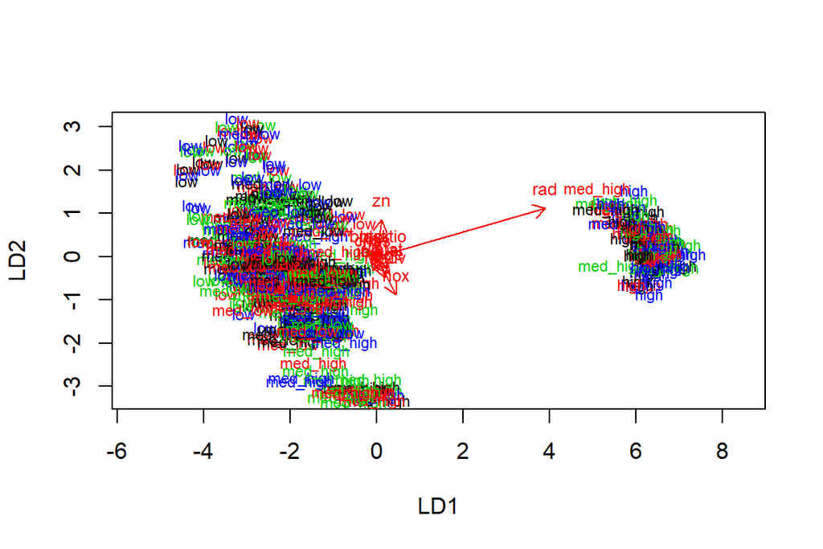

```r
lda.arrows <- function(x, myscale = 1, arrow_heads = 0.1, color = "red", tex = 0.75, choices = c(1,2)){
  heads <- coef(x)
  arrows(x0 = 0, y0 = 0,
         x1 = myscale * heads[,choices[1]],
         y1 = myscale * heads[,choices[2]], col=color, length = arrow_heads)
  text(myscale * heads[,choices], labels = row.names(heads),
       cex = tex, col=color, pos=3)
}
classes <- as.numeric(training_set$crime)
plot(LDA, dimen = 2, col = classes, pch = classes)
lda.arrows(LDA, myscale = 1.2)
```

There is a lot of overlap between the target variable classes (i.e. separation is not great) and the number of predictor variables makes it difficult to interpret how each variable is positioned in relation to each other. Only “nod”, “zn”, and “rad” variables are clearly protruding outwards.

Next we will try to predict the target variable in the test data using the LDA model constructed here.

#### **Predicting “crime” in the test data:**

```r
correct_classes <- test_set$crime
test_set <- dplyr::select(test_set, -crime)
lda.pred <- predict(LDA, newdata = test_set)
table(correct = correct_classes, predicted = lda.pred$class)
```

```
##           predicted
## correct    low med_low med_high high
##   low       13      10        0    0
##   med_low    6      13        2    0
##   med_high   1       8       20    2
##   high       0       0        1   26
```

As we can see, the model performs best when predicting cases of “high” (26 out of 27 = .96) and worst when predicting cases of “low” (13 out of 23 = .57). Overall the accuracy rate for the model in the test data is 72 out of 102 (i.e. ~71%). The model works better than chance level alone (25 %) but there is still room for improvement. One possible reason why the predictive power is not higher could be that many of the [model assumptions](https://en.wikipedia.org/wiki/Linear_discriminant_analysis#Assumptions) were violated (e.g. multivariate normality was not met and the correlations indicated high levels multicollinearity between some the predictors).

#### **K-means clustering:**

According to [Vehkalahti and Everitt (2018)](https://www.crcpress.com/Multivariate-Analysis-for-the-Behavioral-Sciences-Second-Edition/Vehkalahti-Everitt/p/book/9780815385158) “The k-means clustering technique seeks to partition the n individuals in a set of multivariate data into k groups or clusters, (G1, G2,…, Gk), where G*i* denotes the set of n*i* individuals in the *i*th group, and k is given [–] by minimizing some numerical criterion, low values of which are considered indicative of a “good” solution."

That is, we are trying to partition the data into some predetermined number of clusters. Here, we will first run a exploratory k-means algorithm on the scaled (see [scale()](https://www.rdocumentation.org/packages/base/versions/3.6.1/topics/scale); we’ll use scaling to get comparable distances between the variables) Boston dataset and determine appropriate number of cluster based on that. Then we will do another k-means clustering with that number of clusters.

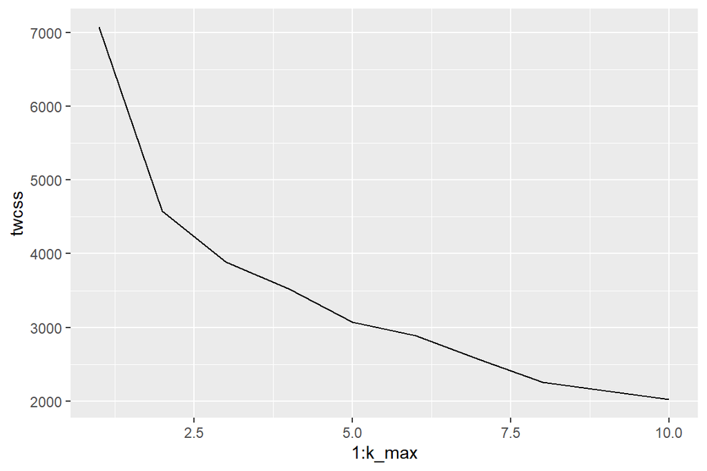

```r
library(MASS)
data("Boston")
DF_Boston <- scale(Boston)
DF_Boston = data.frame(DF_Boston)

k_max <- 10
twcss <- sapply(1:k_max, function(k){kmeans(DF_Boston, k)$tot.withinss})
qplot(x = 1:k_max, y = twcss, geom = 'line')
```

As can be seen from the code, we have specified that we will allow maximum of 10 cluster to be formed. Then we have plotted different cluster solutions against *within cluster sum of squares* (WCSS), which is a measure of the variability of the observations within each cluster. Smaller WCSS indicate more compact clusters.

We will use this plot to spot a solution where the WCSS is as small as possible while number of cluster remains as few as possible. Noticeable “elbow” in the plot occures after 2 cluster solution, so we will proceed with our k-means clustering with k = 2.

```r
km <-kmeans(DF_Boston, centers = 2)
km$size
```

```
## [1] 177 329
```

```r
km$centers
```

```
##         crim         zn      indus         chas        nox         rm
## 1  0.7238295 -0.4872402  1.1425514 -0.005407018  1.0824279 -0.4547830
## 2 -0.3894158  0.2621323 -0.6146857  0.002908943 -0.5823397  0.2446705
##          age        dis        rad        tax    ptratio      black
## 1  0.8051309 -0.8439539  1.0834228  1.1693521  0.5471636 -0.6101842
## 2 -0.4331555  0.4540421 -0.5828749 -0.6291043 -0.2943707  0.3282754
##        lstat       medv
## 1  0.8421083 -0.6566834
## 2 -0.4530491  0.3532917
```

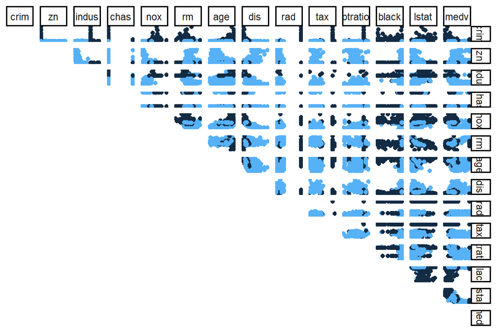

```r
ggpairs(DF_Boston, upper = list(continuous = "points"), lower = NULL, diag = NULL, mapping=ggplot2::aes(colour = km$cluster)) + theme_classic()
```

From the output we can see that there are 177 observations in the first cluster and 329 observations in the second cluster. Below that, each variable mean is presented for clusters 1 and 2. Finally, each variable pair is plotted in a scatterplot and cluster membership is used as a marker.

The colours separate the two cluster groups and show how the clusters are positioned in a bivariate scatterplot for each variable. The plot is quite messy, but for example crime rate (“crim”) variable seems to form distinct patterns for the two clusters when it is plotted against most of the other variables in the data.

#### **Bonus:**

We will perform K-means clustering with k=3, and then LDA using the clusters as target classes.

```r
library(MASS)
data("Boston")
DF_Boston <- scale(Boston)
DF_Boston = data.frame(DF_Boston)
km <-kmeans(DF_Boston, centers = 3)
DF_Boston <- dplyr::mutate(DF_Boston, clusters = km$cluster)

LDA2 <- lda(clusters ~ ., data = DF_Boston)
LDA2
```

```
## Call:
## lda(clusters ~ ., data = DF_Boston)
##
## Prior probabilities of groups:
##         1         2         3
## 0.4169960 0.2687747 0.3142292
##
## Group means:
##         crim         zn      indus         chas        nox         rm
## 1 -0.3775214 -0.3801490 -0.2042579  0.007559575 -0.3267728 -0.2622346
## 2 -0.3984257  1.1594310 -0.9736378 -0.040734936 -0.8281317  0.9623026
## 3  0.8417792 -0.4872402  1.1038563  0.024810573  1.1419809 -0.4751048
##            age         dis        rad        tax     ptratio      black
## 1  0.002272254  0.06397048 -0.5867115 -0.5658967  0.07154588  0.2779966
## 2 -0.928124094  0.90027892 -0.5866634 -0.6778596 -0.79492752  0.3549666
## 3  0.790851768 -0.85494153  1.2803921  1.3307743  0.58499346 -0.6725330
##         lstat       medv
## 1 -0.06379655 -0.1369286
## 2 -0.93647162  1.0185738
## 3  0.88566801 -0.6895226
##
## Coefficients of linear discriminants:
##                 LD1         LD2
## crim    -0.03879941 -0.18360027
## zn      -0.02001502 -0.93462778
## indus    0.48357420  0.09223768
## chas     0.07342283  0.11416112
## nox      0.99906277 -0.73188365
## rm      -0.26441455 -0.53510649
## age     -0.16214470  0.52192109
## dis      0.04189423 -0.28896275
## rad      0.96990974 -0.27662133
## tax      0.98496817 -0.53336839
## ptratio  0.15320599  0.10756465
## black   -0.05207306  0.02440570
## lstat    0.24372886 -0.37814245
## medv    -0.04926589 -0.71641633
##
## Proportion of trace:
##    LD1    LD2
## 0.8609 0.1391
```

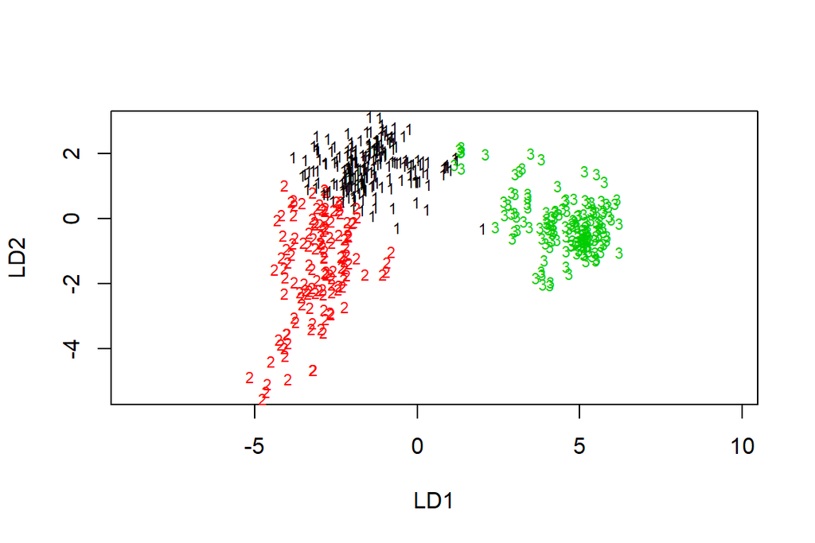

```r
classes <- as.numeric(DF_Boston$clusters)
plot(LDA2, col = classes)
```

Unfortunately I ran out of time, and could not get the arrow function to work properly. So I present the results here with out the arrows. Based on the LD1 & 2 coefficients the most influential variables are “rad”, “nox”, and “tax”.

# **RStudio Exercise 5: Dimensionality Reduction Techniques**

```r
data <- read.csv("C:/Users/OHW/Desktop/R/IODS-project/data/human.csv", row.names = 1)
```

In the first part of the assignment we will be using data obtained from [UNDP](http://hdr.undp.org/en/content/human-development-index-hdi). Some modifications have been made to data (see specifics from here: https://github.com/ohwhalme/IODS-project/blob/master/data/data_ex5.R). Currently the data contains the following variables:

- **Edu2.F**" = Proportion of females with at least secondary education
- **Labo.FM** = Proportion of females in the labour force divided by proportion of males in the labour force
- **Edu.Exp** = Expected years of schooling
- **Life.Exp** = Life expectancy at birth
- **GNI** = Gross National Income per capita
- **Mat.Mor** = Maternal mortality ratio
- **Ado.Birth** = Adolescent birth rate
- **Parli.F** = Percetange of female representatives in parliament

Furthermore, **Country name**s have been assigned as rows in the data frame:

```r
row.names(data)
```

```
##   [1] "Norway"
##   [2] "Australia"
##   [3] "Switzerland"
##   [4] "Denmark"
##   [5] "Netherlands"
##   [6] "Germany"
##   [7] "Ireland"
##   [8] "United States"
##   [9] "Canada"
##  [10] "New Zealand"
##  [11] "Singapore"
##  [12] "Sweden"
##  [13] "United Kingdom"
##  [14] "Iceland"
##  [15] "Korea (Republic of)"
```

[output cut: 140 more lines]

### **Graphical overview of the data and summaries**

```r
str(data)
```

```
## 'data.frame':    155 obs. of  8 variables:
##  $ Edu2.FM  : num  1.007 0.997 0.983 0.989 0.969 ...
##  $ Labo.FM  : num  0.891 0.819 0.825 0.884 0.829 ...
##  $ Edu.Exp  : num  17.5 20.2 15.8 18.7 17.9 16.5 18.6 16.5 15.9 19.2 ...
##  $ Life.Exp : num  81.6 82.4 83 80.2 81.6 80.9 80.9 79.1 82 81.8 ...
##  $ GNI      : int  64992 42261 56431 44025 45435 43919 39568 52947 42155 32689 ...
##  $ Mat.Mor  : int  4 6 6 5 6 7 9 28 11 8 ...
##  $ Ado.Birth: num  7.8 12.1 1.9 5.1 6.2 3.8 8.2 31 14.5 25.3 ...
##  $ Parli.F  : num  39.6 30.5 28.5 38 36.9 36.9 19.9 19.4 28.2 31.4 ...
```

```r
psych::describe(data)
```

```
##           vars   n     mean       sd   median  trimmed      mad    min
## Edu2.FM      1 155     0.85     0.24     0.94     0.87     0.12   0.17
## Labo.FM      2 155     0.71     0.20     0.75     0.73     0.17   0.19
## Edu.Exp      3 155    13.18     2.84    13.50    13.24     2.97   5.40
## Life.Exp     4 155    71.65     8.33    74.20    72.40     7.56  49.00
## GNI          5 155 17627.90 18543.85 12040.00 14552.58 13337.47 581.00
## Mat.Mor      6 155   149.08   211.79    49.00   104.70    63.75   1.00
## Ado.Birth    7 155    47.16    41.11    33.60    41.62    35.73   0.60
## Parli.F      8 155    20.91    11.49    19.30    20.32    11.42   0.00
##                 max     range  skew kurtosis      se
## Edu2.FM        1.50      1.33 -0.76     0.55    0.02
## Labo.FM        1.04      0.85 -0.87     0.05    0.02
## Edu.Exp       20.20     14.80 -0.20    -0.34    0.23
## Life.Exp      83.50     34.50 -0.76    -0.15    0.67
## GNI       123124.00 122543.00  2.14     6.83 1489.48
## Mat.Mor     1100.00   1099.00  2.03     4.16   17.01
## Ado.Birth    204.80    204.20  1.13     0.89    3.30
## Parli.F       57.50     57.50  0.55    -0.10    0.92
```

The data contains 155 observations (rows; i.e. 155 different country names, see above) and 8 variables (columns). The variables have been measured with many different scales, and thus we can see a lot of variation in the variable means, ranges and standard deviations.

Next, let’s inspect how the variable distributions and bivariate relationships look numerically and visually. We’ll do this with bivariate Pearson correlation coefficients and plotting scatterplots and density plots.

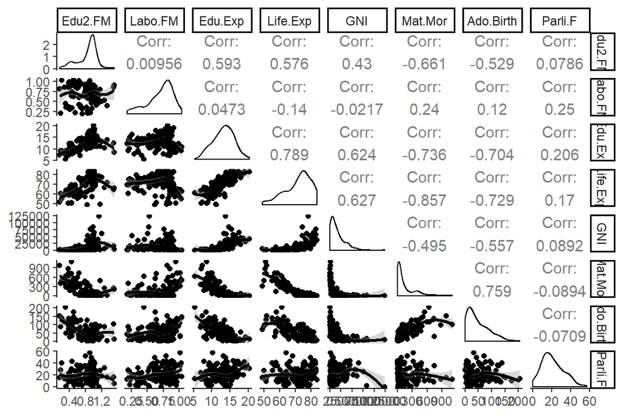

```r
GGally::ggpairs(data, lower = list(continuous = "smooth_loess")) + theme_classic()
```

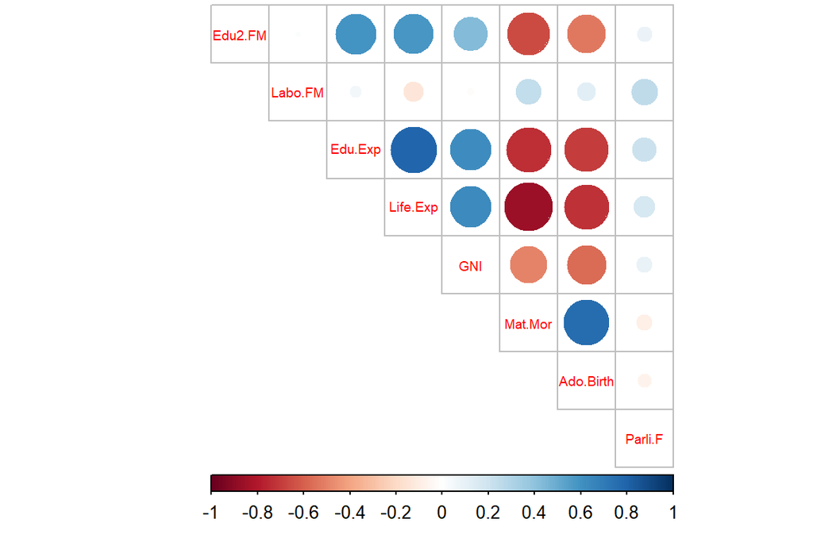

```r
cor_matrix<-round(cor(data), digits = 2)
corrplot::corrplot(cor_matrix, method="circle", type = "upper", cl.pos = "b", tl.pos = "d", tl.cex = 0.6)
```

From the diagonal axis we can see density plots of each of the variables. “Edu.Exp” and “Parli.F” are the only variable that seem roughly normally distributed. All other variables seem more or less skewed (“GNI” and “Mat.Mor.” having particularly extended tail).

Scatterplots in the lower corner indicate that most of the bivariate relationships are curvilinear rather than strictly linear.

Correlation coefficients range from close to zero to over .7 (+/-). Largest correlation is between “Mat.Mor” and “Life.Exp”, where the r = .86. Most of the variables seem to share good amount of variance with each other. However, “Parli.F” and “Labo.FM” are not highly correlated with any of the other variables (all rs < .26), which could prove to be problematic when dimension reduction methods are applied. Also, we should keep in mind, that curvilinear relationship was found for most of the bivariate relationships and outlier were not inspected in-detail, so methods which assume linear relationship between variables might not provide optimal estimators for association.

### **Principal Component Analysis (PCA)**

According to [Vehkalahti and Everitt (2018)](https://www.crcpress.com/Multivariate-Analysis-for-the-Behavioral-Sciences-Second-Edition/Vehkalahti-Everitt/p/book/9780815385158):

> “*The basic goal of PCA is to describe variation in a set of correlated variables, x1, x2,…, xq, in terms of a new set of uncorrelated variables, y1, y2,…, yq, each of which is a linear combination of the x variables. The new variables are derived in decreasing order of “importance” in the sense that y1 accounts for as much as possible of the variation in the original data among all linear combinations of x1, x2,…, xq. Then, y2 is chosen to account for as much as possible of the remaining variation, subject to being uncorrelated with y1, and so on. The new variables defined by this process, y1, y2,…, yq, are the principal components.*”

That is, in essence, PCA is a method to simplify multivariate data with many correlated variables by reducing dimensions in the data.

Next we will perform PCA with the above mentioned UNDP data set. Typically, you would standardize the data before running PCA, so the structure of the principal components would not be dependent on the choice of measurement units. Furthermore, large differences between variance of the variables will result in principal components where the variables with the largest variance tend to dominate the first (and statistically speaking the most important) components. However, to demonstrate this effect, we will initially not standardize the variables.

```r
res.PCA <- FactoMineR::PCA(data, scale.unit = FALSE, ncp = 5, graph = FALSE)
factoextra::get_eigenvalue(res.PCA)
```

```
##         eigenvalue variance.percent cumulative.variance.percent
## Dim.1 3.416674e+08     9.998976e+01                    99.98976
## Dim.2 3.419631e+04     1.000763e-02                    99.99977
## Dim.3 6.302925e+02     1.844566e-04                    99.99996
## Dim.4 1.303570e+02     3.814929e-05                   100.00000
## Dim.5 1.409306e+01     4.124367e-06                   100.00000
## Dim.6 2.436261e+00     7.129774e-07                   100.00000
## Dim.7 3.632356e-02     1.063017e-08                   100.00000
## Dim.8 2.515305e-02     7.361099e-09                   100.00000
```

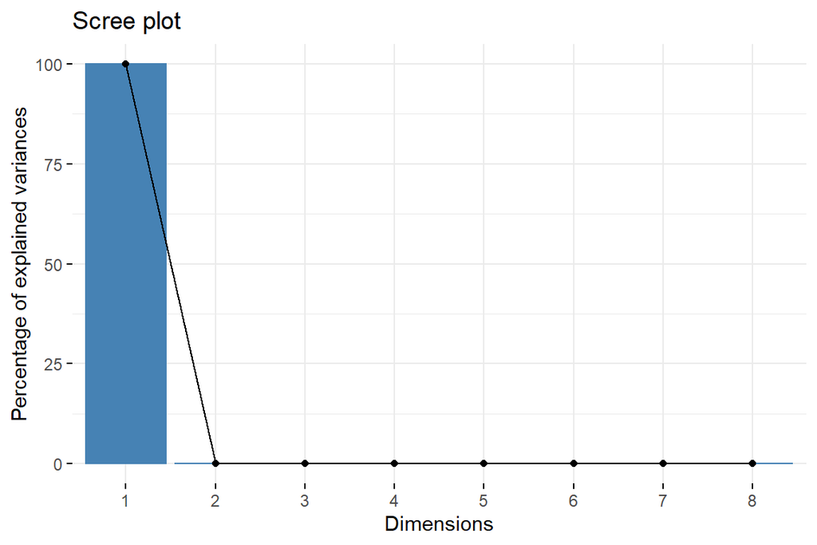

```r
factoextra::fviz_eig(res.PCA)
```

```r
var <- factoextra::get_pca_var(res.PCA)
var$contrib
```

```
##                  Dim.1        Dim.2        Dim.3        Dim.4        Dim.5
## Edu2.FM   3.144375e-09 4.507713e-05 1.164193e-07 7.487478e-06 5.260258e-04
## Labo.FM   5.437968e-12 7.948776e-06 2.812058e-05 2.202029e-03 4.924029e-04
## Edu.Exp   9.144924e-07 5.704745e-03 2.038224e-02 1.097932e-01 2.048277e+00
## Life.Exp  7.928861e-06 8.017406e-02 1.676950e-02 4.559875e-01 9.733094e+01
## GNI       9.999664e+01 3.331951e-03 2.659199e-05 2.433339e-07 1.290185e-06
## Mat.Mor   3.198732e-03 9.833340e+01 1.588361e+00 3.721651e-03 7.095469e-02
## Ado.Birth 1.522659e-04 1.576287e+00 9.836896e+01 2.810691e-03 3.557698e-02
## Parli.F   3.054176e-07 1.044406e-03 5.473531e-03 9.942548e+01 5.132317e-01
```

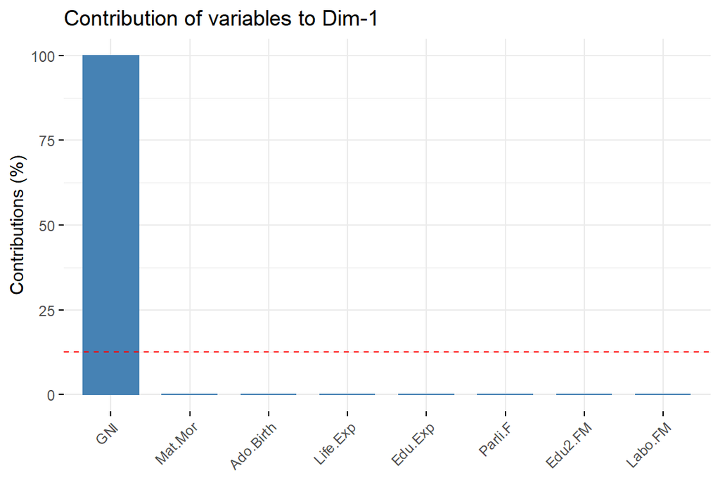

```r
fviz_contrib(res.PCA, choice = "var", axes = 1, top = 10)
```

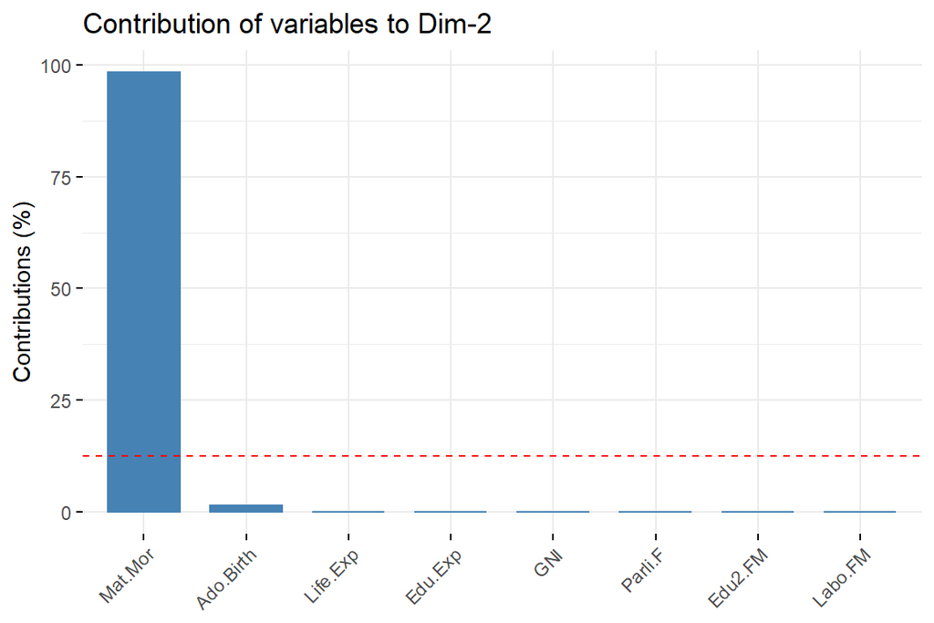

```r
fviz_contrib(res.PCA, choice = "var", axes = 2, top = 10)
```

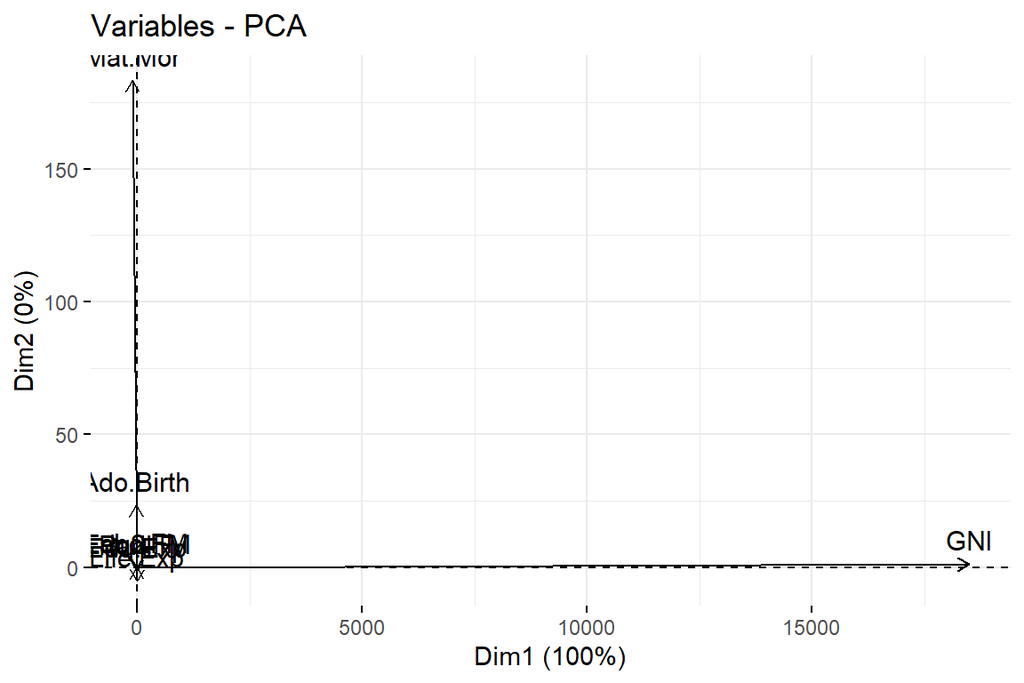

```r
factoextra::fviz_pca_var(res.PCA, col.var = "black")
```

As can be seen from the output, when the variables are not standardized, variables with relatively larger variance (which is caused, in this case, mainly by differences in the measurement scales) completely dominate the retained principal components.

To get more sensible results, we’ll perform the analysis again, this time with standardized variables.

```r
res.PCA2 <- FactoMineR::PCA(data, scale.unit = TRUE, ncp = 5, graph = FALSE)
factoextra::get_eigenvalue(res.PCA2)
```

```
##       eigenvalue variance.percent cumulative.variance.percent
## Dim.1  4.2883701        53.604626                    53.60463
## Dim.2  1.2989625        16.237031                    69.84166
## Dim.3  0.7657100         9.571374                    79.41303
## Dim.4  0.6066276         7.582845                    86.99588
## Dim.5  0.4381862         5.477328                    92.47320
## Dim.6  0.2876242         3.595302                    96.06851
## Dim.7  0.2106805         2.633506                    98.70201
## Dim.8  0.1038390         1.297988                   100.00000
```

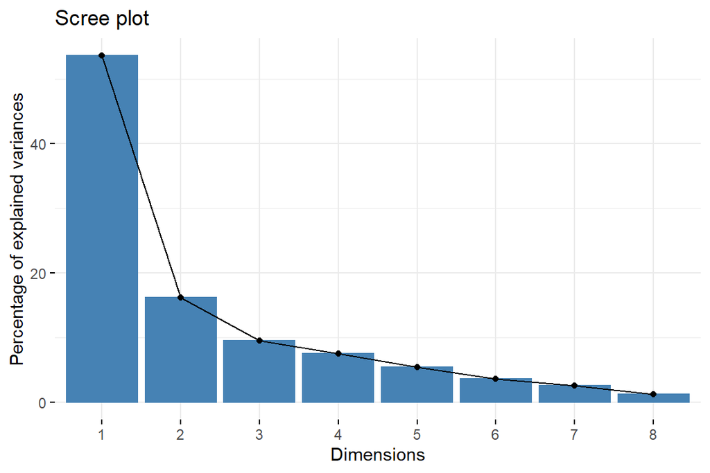

```r
factoextra::fviz_eig(res.PCA2)
```

```r
var2 <- factoextra::get_pca_var(res.PCA2)
var2$contrib
```

```
##                Dim.1       Dim.2      Dim.3       Dim.4     Dim.5
## Edu2.FM   12.7194728  0.14410054  5.8675804 39.28545463 35.803290
## Labo.FM    0.2978742 52.46499737 34.1392117  0.38432864  6.890976
## Edu.Exp   18.2899233  1.94339518  0.5387956  0.49284531  2.754530
## Life.Exp  19.6889566  0.06403294  1.2080878  0.34045117  2.653428
## GNI       12.2838297  0.25612465  4.0677965 52.89314778 24.505531
## Mat.Mor   19.0943638  2.10503163  1.5681398  6.33559805  3.242365
## Ado.Birth 16.9134869  0.59420475  0.0387398  0.24867809 21.828222
## Parli.F    0.7120926 42.42811293 52.5716484  0.01949633  2.321658
```

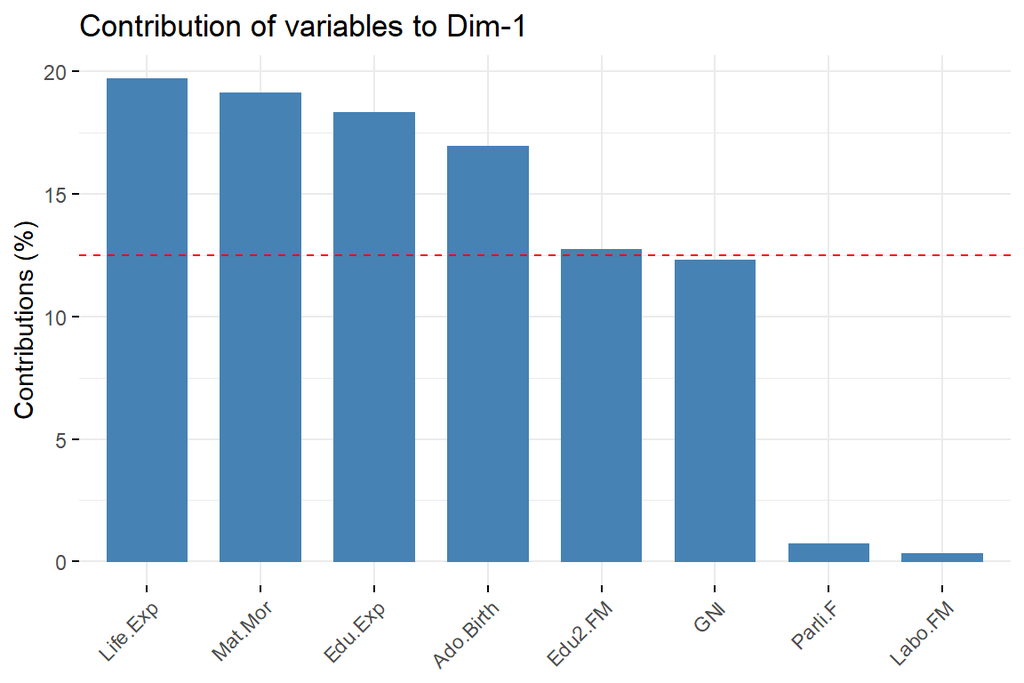

```r
fviz_contrib(res.PCA2, choice = "var", axes = 1, top = 10)
```

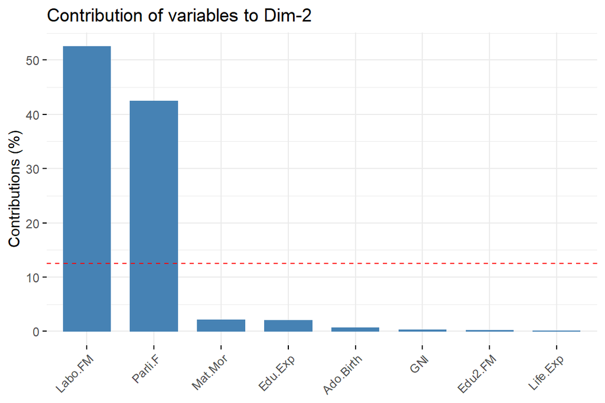

```r
fviz_contrib(res.PCA2, choice = "var", axes = 2, top = 10)
```

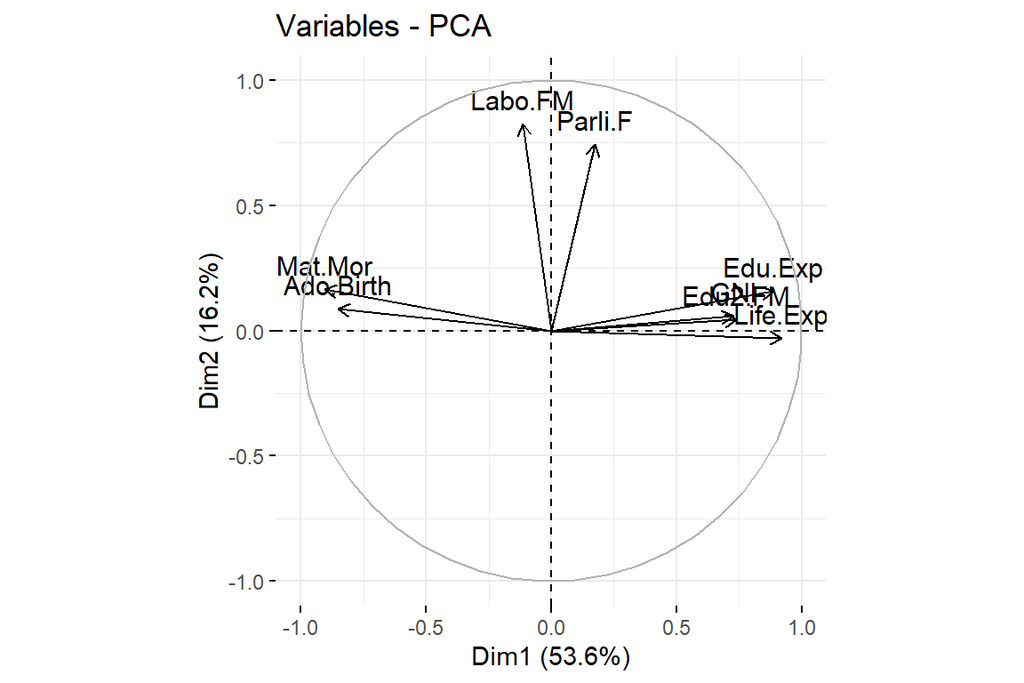

```r
fviz_pca_var(res.PCA2, col.var = "black")
```

Now the two first principal components together retain approximately 70 % of the variation in the orginal data (~54 % and ~16 %, respectively). Component 1 is best depicted by “Life.Exp”, “Mat.Mor”, “Edu.Exp”, and “Ado.Birth”; and component 2 by “Labo.FM” and “Parli.F”.